# AFC - TD

Dans ce TD, nous aborderons la réalisation de l’AFC sous R. Vous devez exécuter l’ensemble des commandes réalisées ici (et les comprendre), afin de pouvoir les reproduire.

En plus des packages présentés ci-dessous, nous devrons utiliser d’autres packages (inclus dans le chargement du package `tidyverse`) pour réaliser les graphiques et autres tableaux.

```r
library(tidyverse)
# library(stringr)
library(formattable)
```

## Package `FactoMiner`

Nous utilisons encore le package [`FactoMineR`](http://factominer.free.fr/) pour réaliser les calculs de l’AFC.

### Données `children`

Nous allons utiliser le jeu de données [`children`](https://rdrr.io/cran/FactoMineR/man/children.html). Celui-ci représente la table de contingence entre les raisons avancées pour ne pas faire d’enfants en lignes, et le niveau d’éducation de la personne répondant en colonnes.

```r
library(FactoMineR)
data(children)
```

|  | unqualified | cep | bepc | high_school_diploma | university | thirty | fifty | more_fifty |
| --- | --- | --- | --- | --- | --- | --- | --- | --- |
| money | 51 | 64 | 32 | 29 | 17 | 59 | 66 | 70 |
| future | 53 | 90 | 78 | 75 | 22 | 115 | 117 | 86 |
| unemployment | 71 | 111 | 50 | 40 | 11 | 79 | 88 | 177 |
| circumstances | 1 | 7 | 5 | 5 | 4 | 9 | 8 | 5 |
| hard | 7 | 11 | 4 | 3 | 2 | 2 | 17 | 18 |
| economic | 7 | 13 | 12 | 11 | 11 | 18 | 19 | 17 |
| egoism | 21 | 37 | 14 | 26 | 9 | 14 | 34 | 61 |
| employment | 12 | 35 | 19 | 6 | 7 | 21 | 30 | 28 |
| finances | 10 | 7 | 7 | 3 | 1 | 8 | 12 | 8 |
| war | 4 | 7 | 7 | 6 | 2 | 7 | 6 | 13 |
| housing | 8 | 22 | 7 | 10 | 5 | 10 | 27 | 17 |
| fear | 25 | 45 | 38 | 38 | 13 | 48 | 59 | 52 |
| health | 18 | 27 | 20 | 19 | 9 | 13 | 29 | 53 |
| work | 35 | 61 | 29 | 14 | 12 | 30 | 63 | 58 |
| comfort | 2 | 4 | 3 | 1 | 4 | NA | NA | NA |
| disagreement | 2 | 8 | 2 | 5 | 2 | NA | NA | NA |
| world | 1 | 5 | 4 | 6 | 3 | NA | NA | NA |
| to_live | 3 | 3 | 1 | 3 | 4 | NA | NA | NA |

### Calcul de l’AFC

On utilise la fonction `CA()`, dont voici les options principales

- `ncp` : nombre de composantes à retenir (5 par défaut)
- `graph` : affiche ou non les deux graphiques (oui par défaut)

Ici, nous ne voulons pas les graphiques tout de suite.

```r
afc = CA(children[,1:5], graph = FALSE)
```

L’objet renvoyé est une liste avec toutes les informations importantes.

```r
names(afc)
```

```
[1] "eig"  "call" "row"  "col"  "svd"
```

Le contenu de cet objet est plutôt bien détaillé (mais en anglais) lorsqu’on l’affiche.

```r
afc
```

```
**Results of the Correspondence Analysis (CA)**
The row variable has  18  categories; the column variable has 5 categories
The chi square of independence between the two variables is equal to 123.8249 (p-value =  4.145257e-05 ).
*The results are available in the following objects:

   name              description
1  "$eig"            "eigenvalues"
2  "$col"            "results for the columns"
3  "$col$coord"      "coord. for the columns"
4  "$col$cos2"       "cos2 for the columns"
5  "$col$contrib"    "contributions of the columns"
6  "$row"            "results for the rows"
7  "$row$coord"      "coord. for the rows"
8  "$row$cos2"       "cos2 for the rows"
9  "$row$contrib"    "contributions of the rows"
10 "$call"           "summary called parameters"
11 "$call$marge.col" "weights of the columns"
12 "$call$marge.row" "weights of the rows"
```

### Variance expliquée

L’objet `eig` est une `matrix`, contenant pour chaque composante :

- la valeur propre
- le pourcentage de variance expliquée
- le pourcentage cumulé de variance expliquée

```r
afc$eig
```

```
       eigenvalue percentage of variance cumulative percentage of variance
dim 1 0.038756492               51.89444                          51.89444
dim 2 0.018885750               25.28778                          77.18222
dim 3 0.008887444               11.90017                          89.08240
dim 4 0.008153629               10.91760                         100.00000
```

On peut donc produire le graphique de la variance expliquée, par composante. Remarquez que le graphique des valeurs propres donnent exactement le même graphique, à l’échelle des ordonnées près (*à tester*).

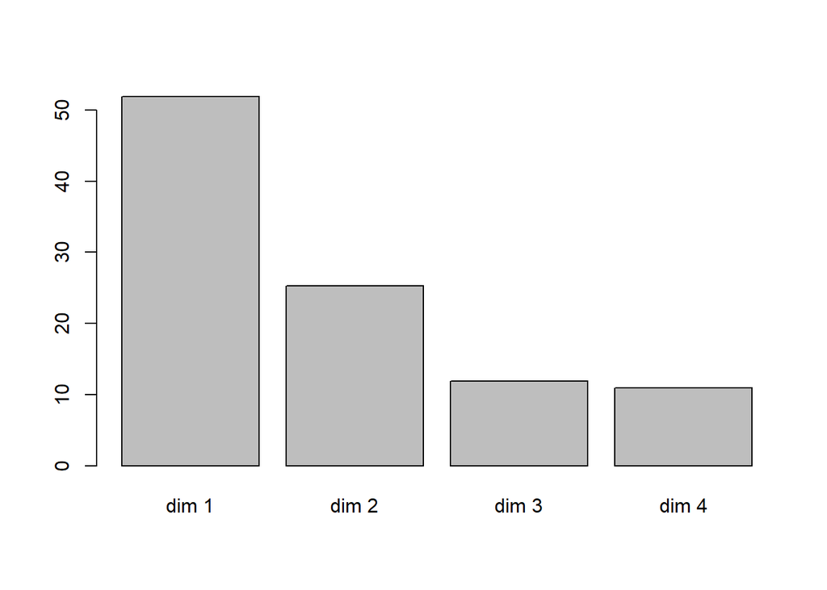

```r
barplot(afc$eig[,2])
```

On peut aussi montrer la variance expliquée cumulée.

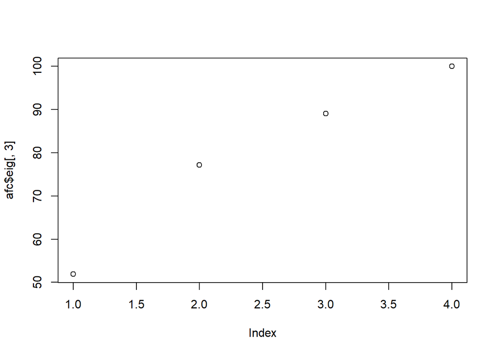

```r
plot(afc$eig[,3])
```

*A faire* : représenter dans un même graphique les deux informations comme ci-dessous par exemple.

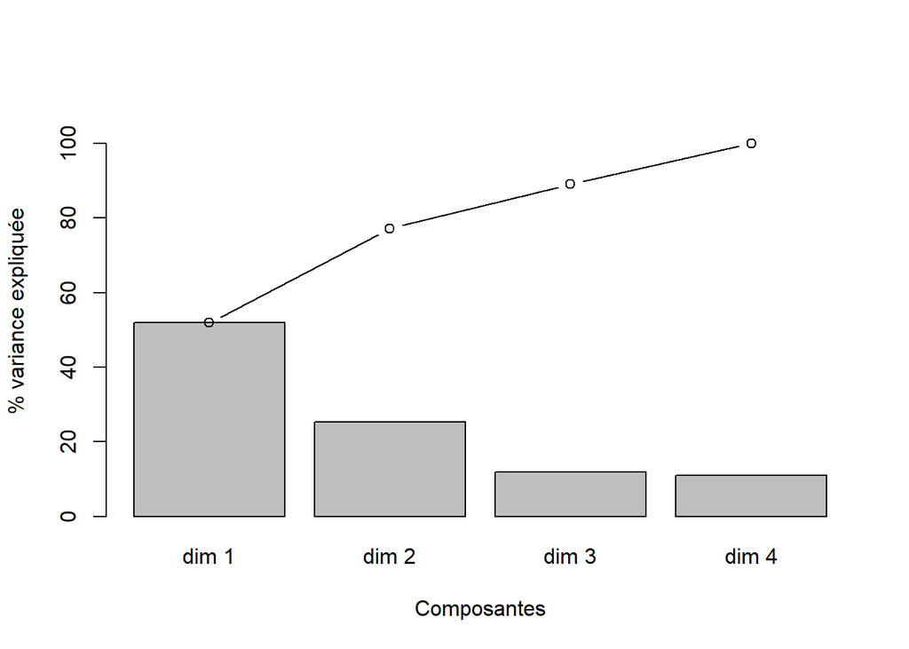

ou

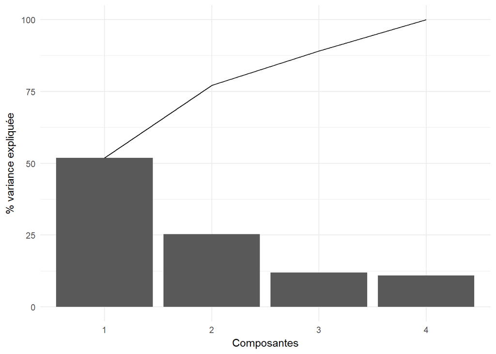

### Représentation graphique

#### Toutes les modalités

Par défaut, lorsqu’on utilise la fonction `plot()` sur l’objet obtenu, on obtient le *premier plan factoriel*, avec les 2 premières composantes.

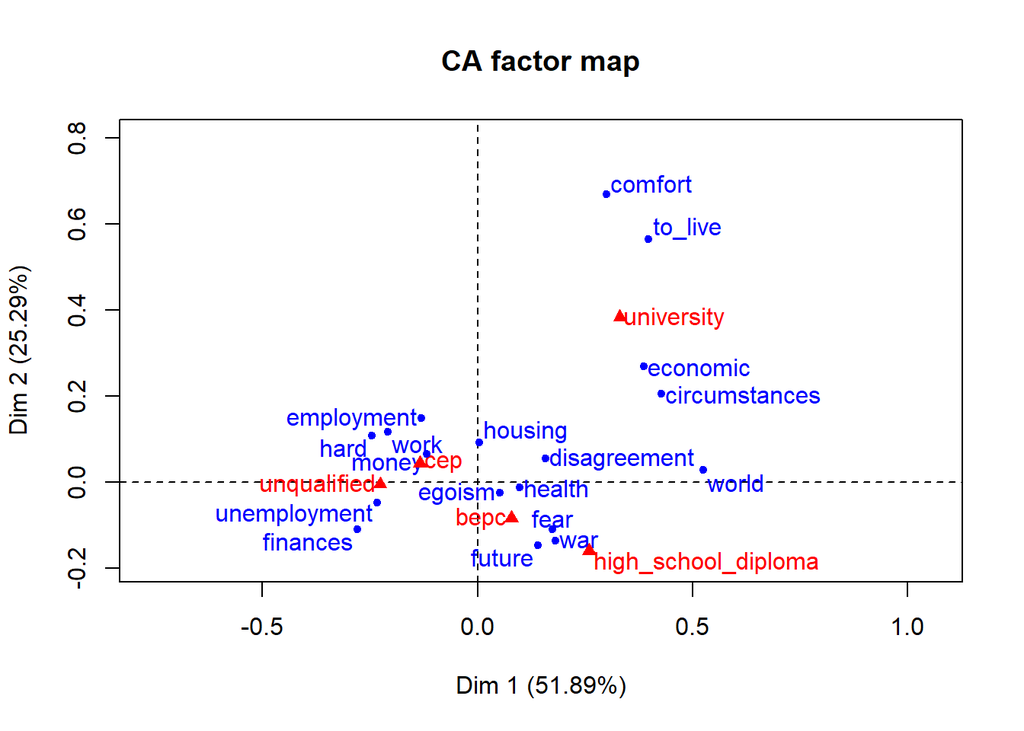

```r
plot(afc)
```

Si on veut choisir les composantes à représenter, nous utilisons le paramètre `axes`.

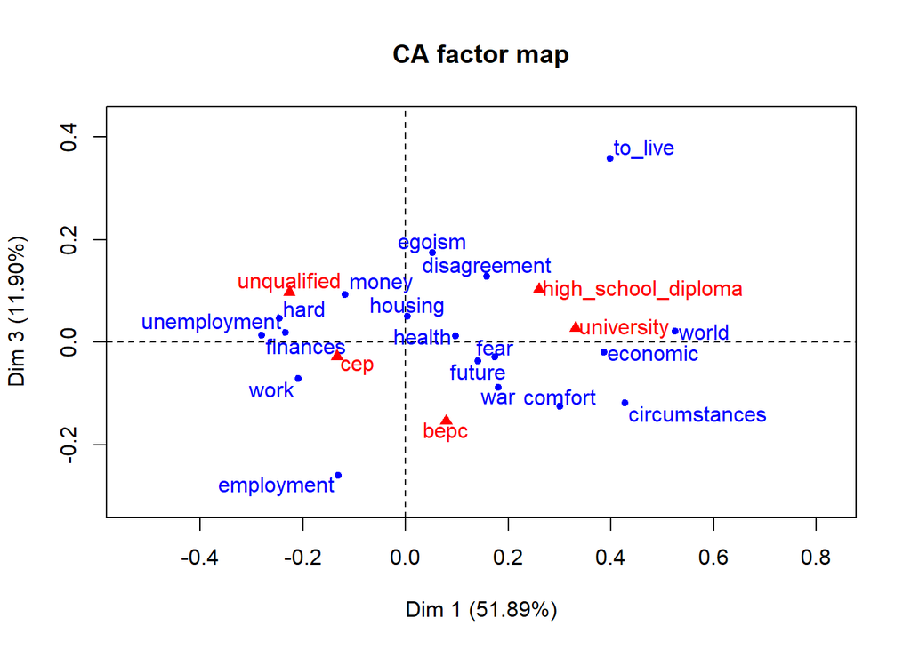

```r
plot(afc, axes = c(1, 3))
```

#### Lignes uniquement

Pour n’avoir que les modalités en lignes, il faut rendre invisibles les colonnes. Ce sont toujours les 2 premières composantes par défaut (et la syntaxe est la même pour changer les composantes).

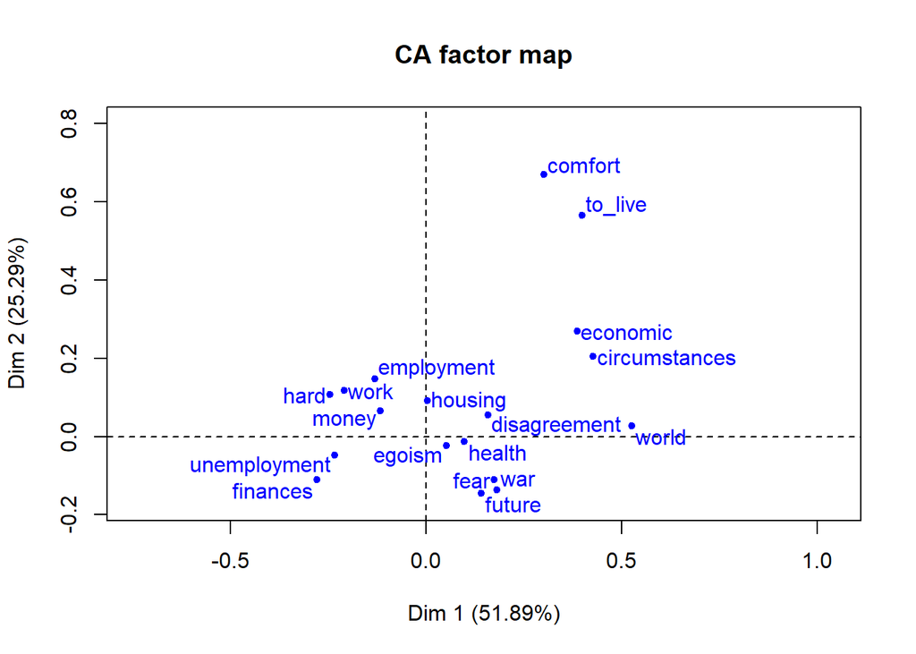

```r
plot(afc, invisible = "col")
```

#### Colonnes uniquement

Et pour n’avoir que les modalités en colonnes, il faut rendre invisibles les lignes.

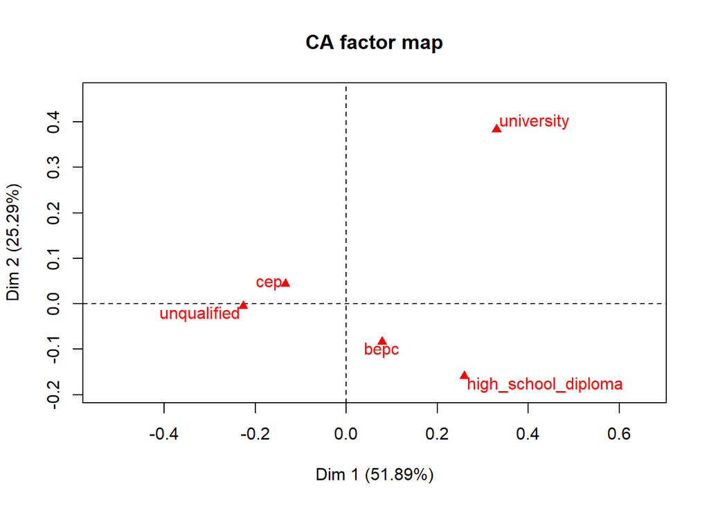

```r
plot(afc, invisible = "row")
```

### Contributions et qualité de représentation

Il est possible d’obtenir la contribution de chaque ligne dans l’objet `contrib`, lui-même dans l’objet `row` du résultat de la fonction. Idem pour les colonnes (sous-objet `contrib` dans l’objet `col`).

Pour la qualité de représentation, celle-ci est stockée dans le sous-objet `cos2` (de `row` pour les lignes et de `col` pour les colonnes).

Ici, vu le nombre de modalités, il est possible de toutes les afficher pour mieux analyser.

```r
round(afc$row$contrib)
```

```
              Dim 1 Dim 2 Dim 3 Dim 4
money             4     3    11     8
future           10    22     3     1
unemployment     24     2     1     1
circumstances     6     3     2     2
hard              3     1     0     0
economic         13    12     0     4
egoism            0     0    22     9
employment        2     6    36     5
finances          3     1     0    26
war               1     2     1     0
housing           0     1     1    18
fear              8     6     1     0
health            1     0     0     2
work             10     7     5     0
comfort           2    20     2     3
disagreement      1     0     2    15
world             8     0     0     2
to_live           3    14    12     2
```

```r
round(afc$row$cos2, 2)
```

```
              Dim 1 Dim 2 Dim 3 Dim 4
money          0.43  0.14  0.26  0.17
future         0.46  0.50  0.03  0.01
unemployment   0.94  0.04  0.01  0.01
circumstances  0.72  0.17  0.06  0.06
hard           0.81  0.16  0.03  0.01
economic       0.65  0.31  0.00  0.04
egoism         0.06  0.01  0.67  0.26
employment     0.15  0.19  0.59  0.07
finances       0.36  0.06  0.00  0.58
war            0.53  0.30  0.13  0.04
housing        0.00  0.15  0.04  0.81
fear           0.70  0.28  0.02  0.00
health         0.75  0.01  0.01  0.23
work           0.70  0.22  0.08  0.00
comfort        0.16  0.77  0.03  0.05
disagreement   0.16  0.02  0.11  0.71
world          0.95  0.00  0.00  0.05
to_live        0.25  0.51  0.20  0.03
```

Il faut faire de même pour les colonnes (*à tester*).

### Interprétation

#### Nombre de composantes

Si nous regardons la variance cumulée, nous remarquons qu’avec 2 composantes, nous expliquons 77% de l’information, et 89% avec 3 axes.

#### Axe 1

Le premier axe est très lié aux modalités suivantes (selon leur contribution) :

- en lignes : `unemployment` (à gauche), `economic` (à droite), ainsi que `future` et `work` dans une moindre mesure
- en colonnes : `high_school_diploma`, `university` (oute deux à droite) et `unqualified` (à gauche)

#### Axe 2

Cet axe est à prendre avec beaucoup de distance. En effet, vu le peu d’informations qu’il apporte, dans le cadre de l’AFC, il faut être méfiant envers une interprétation trop poussée de cet axe.

Si on devait tout de même l’interpréter, voici les modalités importantes :

- en lignes : `comfort` et `to_live` (en haut) et `future` (en bas)
- en colonnes : `university` (en haut) et `high_school_diploma` (en bas)

Ici, nous pourrions dire, avec la plus grande des mesures, que les personnes à haut niveau de qualification indique que la perte de confort est une cause importante pour ne pas avoir d’enfant.

## FactoInvestigate

En plus du package `FactoMineR`, il existe le package [`FactoInvestigate`](http://factominer.free.fr/reporting/index_fr.html) qui permet de créer un rapport automatique pour l’interprétation d’un résultat d’une fonction de `FactoMineR` (ici, de `CA()` donc).

Voila comment lancer la création du rapport.

```r
library(FactoInvestigate)
Investigate(afc, file = "Investigate-AFC.Rmd")
```

## Package `Factoshiny`

Dans le même état d’esprit, le package [`Factoshiny`](http://factominer.free.fr/graphs/factoshiny-fr.html) permet lui de lancer une application dans un navigateur web pour réaliser une analyse des résultats, ainsi que pour exporter des graphiques et récupérer des tableaux. Voici comment lancer l’application :

```r
library(Factoshiny)
CAshiny(afc)
```

## A faire

Merci de produire un document `Rmarkdown` contenant l’ensemble du code et des commentaires.

### Suite sur `children`

- Définir comme éléments supplémentaires les lignes 15 à 18, et les colonnes 6 à 8
- Analyser les différences entre les deux AFC

### Commerces de Paris

La mairie de Paris met à disposition, sur son site [Open Data](http://opendata.paris.fr), l’ensemble des [commerces de Paris](https://opendata.paris.fr/explore/dataset/commercesparis/), en 2014. Les données sont disponibles dans le fichier `commercesparis.csv`. Les informations sur les variables sont disponibles sur le site.

```r
# importation des données
commerces = read.table("commercesparis.csv",
                       header = T, sep = ";", quote = '"',
                       fileEncoding = "UTF-8")

# retrait du commerce sans activité
commerces = subset(commerces, CODE.ACTIVITE != "")
```

En regardant la liste des activités (ici les 20 premières), nous remarquons que nous pouvons sûrement regroupés celles-ci en groupes, à partir des deux premières lettres.

```r
#
activite = subset(commerces, select = c(CODE.ACTIVITE, LIBELLE.ACTIVITE))
activite = unique(activite[order(activite$CODE.ACTIVITE),])
head(activite, 20)
```

```
     CODE.ACTIVITE                                    LIBELLE.ACTIVITE
10           AA101                                      Locaux Vacants
62           AA102                                   Locaux en travaux
170          AB101                        Commerce de gros alimentaire
222          AB102                Commerce de gros fabrication textile
44           AB103            Commerce de gros fabrication habillement
1761         AB104         Commerce de gros maroquinerie et chaussures
7686         AB105                         Commerce de gros bijouterie
95           AB106                              Autre commerce de gros
12           AC101                                          Imprimerie
2            AC102                    Services annexes aux entreprises
2144         AC103                Studio de reportages photographiques
764          AD101                                     Cabinet médical
407          AD102                                Centre de radiologie
582          AD103                                    Cabinet dentaire
51           AD104                         Cabinet de kinésithérapeute
453          AD105                                Cabinet d'infirmière
281          AD106 Autre activité d'auxiliaire médical - Orthophoniste
596          AD107                                          Ambulances
418          AD108                    Laboratoire d'analyses médicales
429          AD109                                         Vétérinaire
```

```r
table(substr(commerces$CODE.ACTIVITE, 1, 2))
```

```
   AA    AB    AC    AD    AE    AF    CA    CB    CC    CD    CE    CF
 7659  2002   537  1763   221  9546  7214  8767  2706  3161  5798   939
   CG    CH    CI    GM    SA    SB
  933 13823  1871     8 12343  4553
```

Pour leur attribuer un nom, nous allons créer un `data.frame`, que nous joindrons à la table d’origine pour ensuite pouvoir l’utiliser.

```r
act = read.table(text = "CODE;ACTIVITE
AA;Locaux non utilisés
AB;Commerces de gros
AC;Imprimerie, Service annexe, Studio reportage
AD;Activité de santé
AE;Lieu de spectacle
AF;Chose en boutique
CA;Alimentaire
CB;Mode
CC;Pharmacie et produits de santé
CD;Equipements
CE;Ventes diverses
CF;Bricolage, jardinage
CG;Automobile, moto
CH;Restauration
CI;Hôtelerie
GM;Grand magasin
SA;Services diverses
SB;Banques
", sep = ";", header = T
)
commerces = merge(
  transform(commerces,
          CODE = substr(CODE.ACTIVITE, 1, 2)),
  act
)
```

Vous devez donc réaliser les étapes suivantes :

- Créer la table de contingence entre les arrondissements et le code d’activité nouvellement créé
- Décrire rapidement les données
- Réaliser une AFC
- Produire les graphiques nécessaires à l’interprétation
- Que peut-on dire globalement ?